# Exploratory-Regression-Project

Stephen Fekete

2025-04-25

## Project Summary

This project investigates long-term precipitation patterns using weather station data across South East Queensland. We focus on identifying and analysing stations with over 110 years of continuous precipitation records from the GHCN-D dataset. After filtering metadata for these criteria, we visualise spatial distribution using map-based tools and prepare the data for further statistical analysis. The project leverages R packages including `dplyr`, `ggplot2`, and `ggmap` for data processing and geospatial visualisation.

## Preprocessing the Meta Data

```r
# Load required libraries for data manipulation and visualisation
library(dplyr)    # For data manipulation (filtering, summarising, etc.)
```

```r
library(ggplot2)  # For creating plots and visualisations
library(ggmap)    # For map-based visualisations using spatial data
# Load datasets from CSV files into data frames
meta_data <- read.csv("ghcnd_meta_data.csv")    # Metadata about weather stations
station_data <- read.csv("station_data.csv")    # Daily precipitation data for stations
readRenviron(".Renviron")
Sys.getenv("STADIA_API_KEY")
```

```
## [1] "7d4a6400-e693-437c-b0a9-cdf13e634359"
```

```r
register_stadiamaps(key = Sys.getenv("STADIA_API_KEY"))

# Check if the Stadia Maps API key has been successfully registered
has_stadiamaps_key()
```

```
## [1] TRUE
```

```r
# Filter the meta_data for stations that meet specific criteria:
filtered_meta <- meta_data %>%
  filter(
    element == "PRCP",                          # Only include stations that record precipitation
    (last_year - first_year) >= 110,            # Include stations with at least 110 years of data
    longitude >= 138 & longitude <= 155,        # Limit to stations within specified longitude range (South East Queensland)
    latitude >= -29.5 & latitude <= -26         # Limit to stations within specified latitude range (South East Queensland)
  )

# Display the first few rows of the filtered_meta dataframe to check the results
head(filtered_meta)
```

|  | id | latitude | longitude | elevation | name | element | first_year | last_year |
| --- | --- | --- | --- | --- | --- | --- | --- | --- |
| 1 | ASN00017016 | -27.0194 | 138.8933 | 32 | GOYDERS LAGOON (CLIFTON HILLS) | PRCP | 1894 | 2020 |
| 2 | ASN00017019 | -26.7061 | 140.6261 | 71 | CORDILLO DOWNS | PRCP | 1883 | 2014 |
| 3 | ASN00017020 | -27.7017 | 138.3361 | 7 | MUNGERANIE (COWARIE) | PRCP | 1881 | 2017 |
| 4 | ASN00017028 | -27.7240 | 140.7633 | 53 | INNAMINCKA STATION | PRCP | 1882 | 2021 |
| 5 | ASN00017067 | -28.0183 | 138.6637 | 60 | MUNGERANIE | PRCP | 1887 | 2013 |
| 6 | ASN00017089 | -27.7205 | 138.2548 | 5 | MUNGERANIE (KALAMURINA) | PRCP | 1884 | 2021 |

```r
# Count the number of rows (i.e., number of stations) in the filtered_meta dataframe
# Each row represents one weather station that met all the filter criteria
nrow(filtered_meta)
```

```
## [1] 214
```

## Exploratory Visualisation

Basic Scatterplot of Station Locations and Elevation This scatterplot displays the station locations, with elevation represented through color.

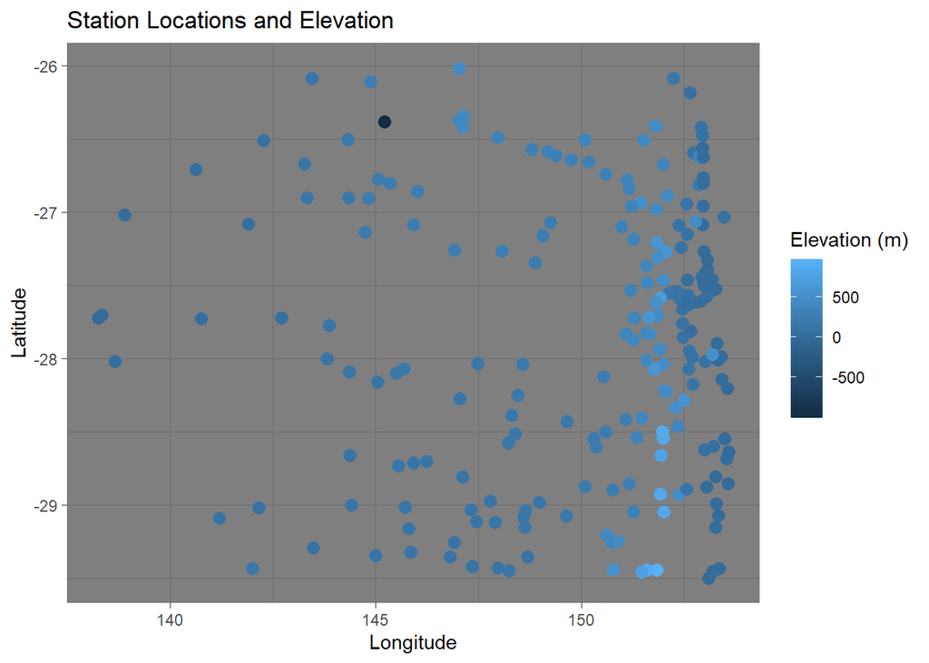

```r
# Create a scatterplot of station locations, with elevation represented by color
ggplot(filtered_meta, aes(x = longitude, y = latitude, color = elevation)) +
  geom_point(size = 3) +  # Plot each station as a point, size 3 for visibility
  labs(
    title = "Station Locations and Elevation",  # Title of the plot
    x = "Longitude",                            # Label for the x-axis
    y = "Latitude",                             # Label for the y-axis
    color = "Elevation (m)"                     # Legend title for elevation color scale
  ) +
  theme_dark()  # Apply a dark theme for visual contrast
```

## Map-Based Visualisation with Stadia Maps

Map-Based Visualisation Using ggmap. This enhanced visualisation overlays station locations on a map of South East Queensland for better spatial context. Elevation is again color-coded.

```r
# Define the bounding box for the map, slightly larger than SEQ for better visual clarity
qld <- c(left = 138, bottom = -31, right = 155, top = -24.5)

# Retrieve a terrain map of the specified region from Stadia Maps
map <- get_stadiamap(bbox = qld, zoom = 6, maptype = "stamen_terrain")
```

```
## ℹ © Stadia Maps © Stamen Design © OpenMapTiles © OpenStreetMap contributors.
```

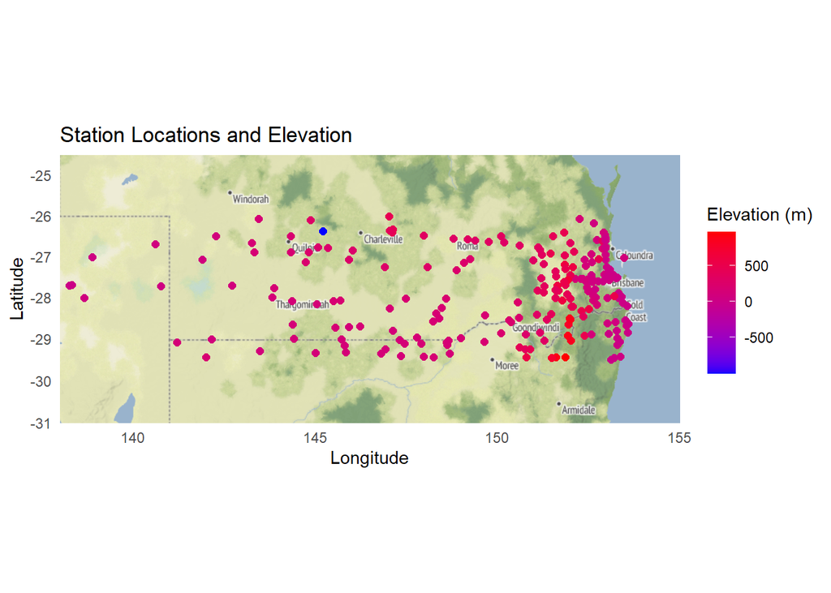

```r
# Overlay station locations onto the map with elevation represented by color
ggmap(map) +
  geom_point(
    data = filtered_meta,                       # Use filtered_meta data for plotting
    aes(x = longitude, y = latitude, color = elevation),  # Plot longitude vs latitude, color by elevation
    size = 2                                    # Set point size for readability
  ) +
  scale_color_gradient(low = "blue", high = "red") +  # Elevation color gradient: blue for low, red for high
  labs(
    title = "Station Locations and Elevation",  # Title of the plot
    x = "Longitude",                            # X-axis label
    y = "Latitude",                             # Y-axis label
    color = "Elevation (m)"                     # Legend title for elevation
  ) +
  theme_minimal()  # Use a clean, minimal theme for a clear presentation
```

## Handling Missing Values

Note on Outlier Impact: As seen in the visualisation and confirmed by the summary of elevation values, there is an outlier at -999m, which likely indicates missing data according to the GHCND documentation. While this outlier appears only once in this subset, it distorts the elevation color gradient, and therefore should be addressed to ensure accurate visualisation and analysis.

```r
# Display the lowest elevation values from filtered_meta to help identify potential outliers
filtered_meta %>%
  arrange(elevation) %>%    # Sort the data frame in ascending order of elevation (lowest values first)
  select(name, elevation) %>%  # Select only the 'name' and 'elevation' columns for display
  head()                     # Show the first 6 rows (default for head) with the lowest elevation values
```

|  | name | elevation |
| --- | --- | --- |
| 1 | BOOTHULLA | -999.9 |
| 2 | SANDGATE POST OFFICE | 1.0 |
| 3 | BALLINA (CROWLEY VILLAGE) | 3.0 |
| 4 | BYRON BAY (JACARANDA DRIVE) | 3.0 |
| 5 | CABOOLTURE POST OFFICE | 3.9 |
| 6 | MUNGERANIE (KALAMURINA) | 5.0 |

## Cleaned Map Without Missing Elevation Values

Cleaned Visualisation Excluding Missing Elevation (-999) To correct the color gradient distortion, the -999 elevation value is excluded based on the dataset guidelines (values of -999 or similar indicate missing data).

```r
# Remove invalid elevation values (-999 indicates missing data according to GHCND documentation)
filtered_meta_clean <- filtered_meta %>%
  filter(elevation > -999)  # Keep only rows where elevation is valid (> -999)

# Define the bounding box for the map, slightly larger than SEQ for better visual clarity
qld <- c(left = 138, bottom = -31, right = 155, top = -24.5)

# Retrieve a terrain map of the specified region from Stadia Maps
map <- get_stadiamap(bbox = qld, zoom = 6, maptype = "stamen_terrain")
```

```
## ℹ © Stadia Maps © Stamen Design © OpenMapTiles © OpenStreetMap contributors.
```

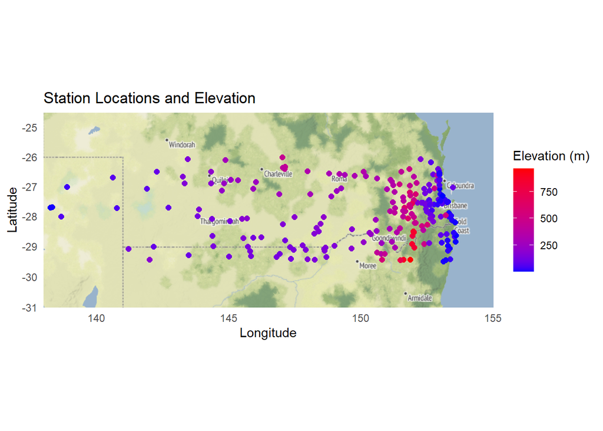

```r
# Plot station locations using cleaned data (without invalid elevation values)
ggmap(map) +
  geom_point(
    data = filtered_meta_clean,                   # Use the cleaned dataset for plotting
    aes(x = longitude, y = latitude, color = elevation),  # Plot longitude vs latitude, color by elevation
    size = 2                                      # Set point size for readability
  ) +
  scale_color_gradient(low = "blue", high = "red") +  # Elevation color gradient: blue for low, red for high
  labs(
    title = "Station Locations and Elevation",    # Title of the plot
    x = "Longitude",                              # X-axis label
    y = "Latitude",                               # Y-axis label
    color = "Elevation (m)"                       # Legend title for color scale
  ) +
  theme_minimal()  # Use a clean, minimal theme for a clear presentation
```

## Merging and Summarising Rainfall Data

```r
# Join the daily station data with the cleaned South East Queensland (SEQ) station metadata
seq_rain_data <- station_data %>%
  inner_join(filtered_meta_clean, by = "id")  # Perform an inner join on the 'id' column to combine matching rows

# View the first few rows of the combined dataset to confirm the join was successful
head(seq_rain_data)
```

|  | id | date | prcp | latitude | longitude | elevation | name | element | first_year | last_year |
| --- | --- | --- | --- | --- | --- | --- | --- | --- | --- | --- |
| 1 | ASN00046037 | 1886-04-01 | 0 | -29.4345 | 142.0098 | 183 | TIBOOBURRA POST OFFICE | PRCP | 1886 | 2016 |
| 2 | ASN00046037 | 1886-04-02 | 0 | -29.4345 | 142.0098 | 183 | TIBOOBURRA POST OFFICE | PRCP | 1886 | 2016 |
| 3 | ASN00046037 | 1886-04-03 | 0 | -29.4345 | 142.0098 | 183 | TIBOOBURRA POST OFFICE | PRCP | 1886 | 2016 |
| 4 | ASN00046037 | 1886-04-04 | 0 | -29.4345 | 142.0098 | 183 | TIBOOBURRA POST OFFICE | PRCP | 1886 | 2016 |
| 5 | ASN00046037 | 1886-04-05 | 0 | -29.4345 | 142.0098 | 183 | TIBOOBURRA POST OFFICE | PRCP | 1886 | 2016 |
| 6 | ASN00046037 | 1886-04-06 | 0 | -29.4345 | 142.0098 | 183 | TIBOOBURRA POST OFFICE | PRCP | 1886 | 2016 |

```r
# Calculate the mean and median rainfall for each station, excluding days with zero rainfall
rain_summary <- seq_rain_data %>%
  filter(prcp > 0) %>%  # Exclude observations where rainfall is zero to focus on actual rainfall events
  group_by(name) %>%    # Group the data by station name
  summarise(
    mean_rainfall = mean(prcp, na.rm = TRUE),     # Calculate the mean rainfall for each station, ignoring any NA values
    median_rainfall = median(prcp, na.rm = TRUE)  # Calculate the median rainfall for each station, ignoring any NA values
  )

# Display the resulting summary table of mean and median rainfall per station
print(rain_summary)
```

```
## # A tibble: 8 × 3
##   name                     mean_rainfall median_rainfall
##   <chr>                            <dbl>           <dbl>
## 1 BEECHAL                          109.               62
## 2 BRISBANE REGIONAL OFFICE          93.7              30
## 3 CASINO AIRPORT                    95.4              40
## 4 GOODOOGA (BRENDA)                101.               58
## 5 HELIDON POST OFFICE              110.               54
## 6 INNAMINCKA STATION               113.               65
## 7 MARYLAND                          81.6              36
## 8 TIBOOBURRA POST OFFICE            71.6              30
```

## Rainfall Distribution by Station

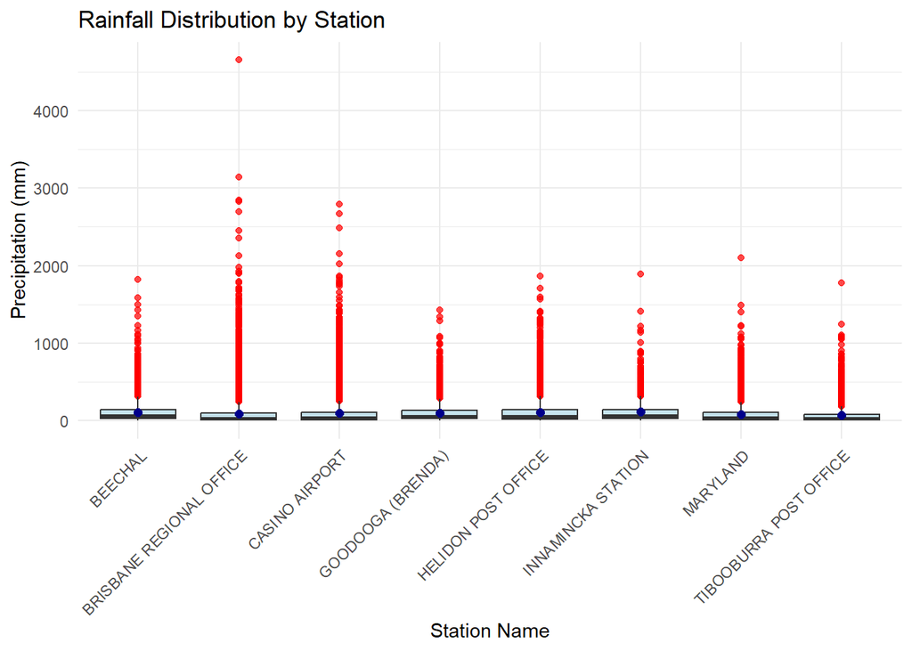

```r
# Filter the data to exclude days with zero rainfall
rain_data_filtered <- seq_rain_data %>%
  filter(prcp > 0)  # Keep only observations where rainfall was greater than 0 mm

# Create a boxplot to compare rainfall distributions across stations, with mean values highlighted
ggplot(rain_data_filtered, aes(x = name, y = prcp)) +
  geom_boxplot(outlier.color = "red", fill = "lightblue", alpha = 0.7) +  # Draw boxplots for each station, highlight outliers in red
  stat_summary(fun = mean, geom = "point", shape = 20, size = 3, color = "darkblue") +  # Overlay the mean as dark blue dots
  labs(
    title = "Rainfall Distribution by Station",  # Title of the plot
    x = "Station Name",                         # Label for x-axis (station names)
    y = "Precipitation (mm)"                    # Label for y-axis (rainfall amount in mm)
  ) +
  theme_minimal() +  # Apply a minimal theme for a clean look
  theme(axis.text.x = element_text(angle = 45, hjust = 1))  # Rotate x-axis labels for better readability
```

## Log-Scaled Visualisation

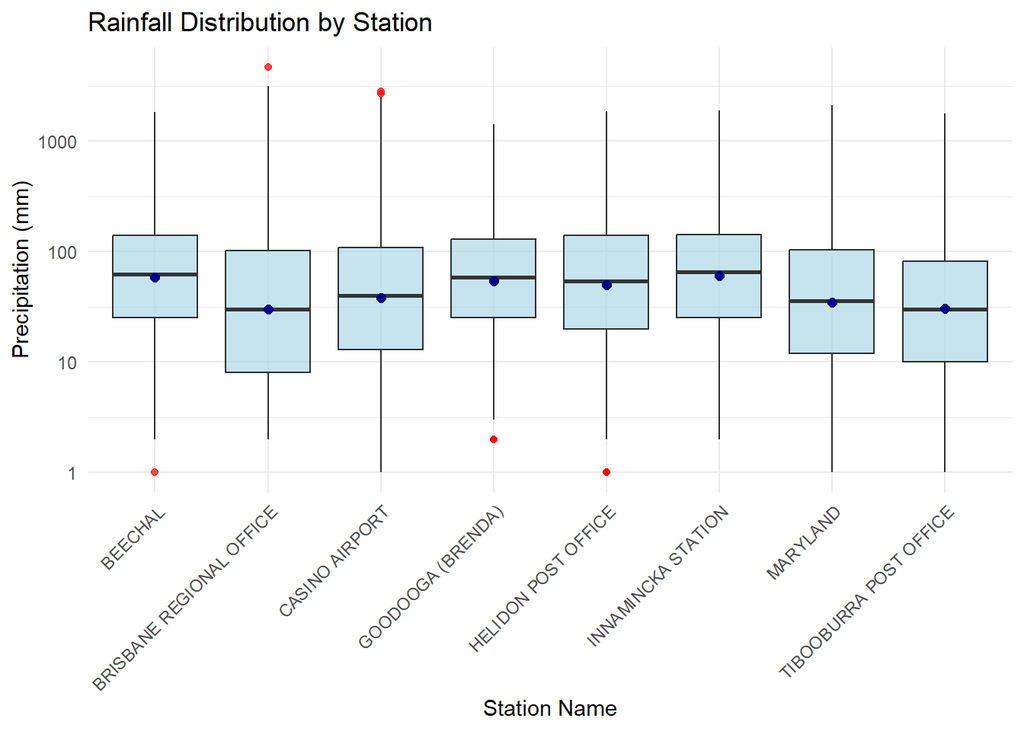

```r
# Apply a log scale to better visualise skewed rainfall data
ggplot(rain_data_filtered, aes(x = name, y = prcp)) +
  geom_boxplot(outlier.color = "red", fill = "lightblue", alpha = 0.7) +  # Draw boxplots for each station, highlight outliers in red
  stat_summary(fun = mean, geom = "point", shape = 20, size = 3, color = "darkblue") +  # Overlay the mean as dark blue dots
  scale_y_log10() +  # Log scale compresses high outliers
  labs(
    title = "Rainfall Distribution by Station",  # Title of the plot
    x = "Station Name",                         # Label for x-axis (station names)
    y = "Precipitation (mm)"                    # Label for y-axis (rainfall amount in mm)
  ) +
  theme_minimal() +  # Apply a minimal theme for a clean look
  theme(axis.text.x = element_text(angle = 45, hjust = 1))  # Rotate x-axis labels for better readability
```

## Conclusion

This project successfully identified and visualized long-term precipitation stations in South East Queensland using the GHCN-D dataset. Spatial and elevation-based mapping revealed potential data anomalies (e.g., -999 elevation values), which were cleaned to ensure reliable interpretation. Rainfall distribution analysis further highlighted the naturally skewed nature of precipitation data. By applying log transformations and summary statistics, clearer patterns emerged that can support further climatological or statistical modelling.